# Using Shiny to Visualize Regional Proportional Representation for Canada, federally since 1921

18 Aug 2022

## What this presentation is not

1. A crash course in precise mathematical definitions from psephology
2. A comparison of all alternate voting systems in use…
3. or even all variations of proportional representation (PR)
4. A litigation of arguments for or against any particular voting system
5. An examination at hypotheticals for any state other than Canada, or for Canada’s provincial / territorial legislatures

## Another way to describe FPTP: “Winner Take All (WTA)”

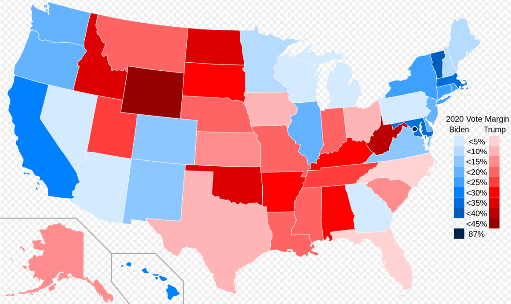

2020 U.S. presidential election, margin of victory by state

Source: [Wikimedia Commons](https://commons.wikimedia.org/wiki/File:2020_U.S._presidential_election_margins.svg)

## Extreme example of FPTP

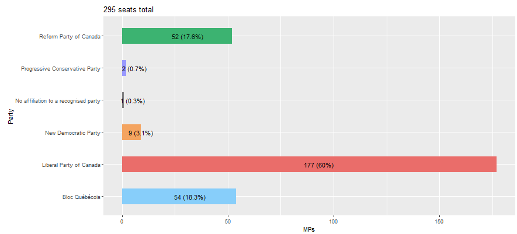

1993 federal election seat results

## …continued: 1993 federal vote share

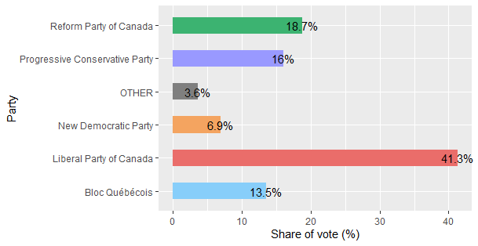

1993 federal election vote share

## …continued: 1993 federal discrepancy

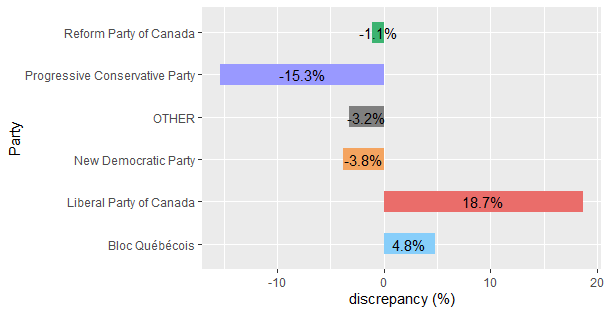

Discrepancy is defined as difference between seats and vote share

## Moving on to Quebec

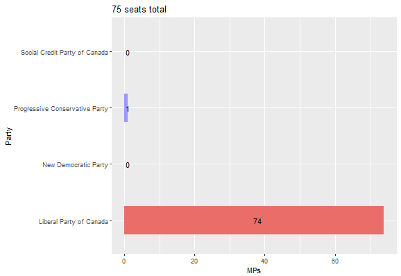

1980 federal election, Quebec seat results

## …continued: 1980 Quebec vote share

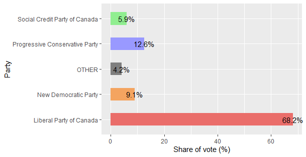

1980 federal election, Quebec vote share

## …continued: 1980 Quebec discrepancy

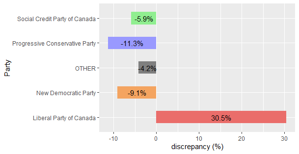

Discrepancy is defined as difference between seats and vote share

## D’Hondt method

\(\text{quotient} = \frac{V}{s+1}\), where:

- \(V\) is the total votes cast for the party in the specified political entity
- \(s\) is the total seats allocated for the party in the specified political entity. Initially set to 0 for all parties.

Gallagher, Michael (1991). [“Proportionality, disproportionality and electoral systems”](https://web.archive.org/web/20131116104818/http://www.tcd.ie/Political_Science/staff/michael_gallagher/ElectoralStudies1991.pdf) *Electoral Studies*. **10** (1): 34.

## Example calculation of the D’Hondt method:

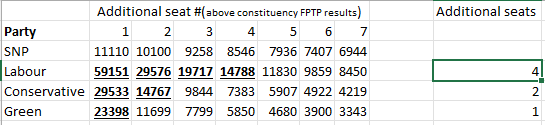

2016 Scottish Parliament election, Glasgow region

## Intended final product

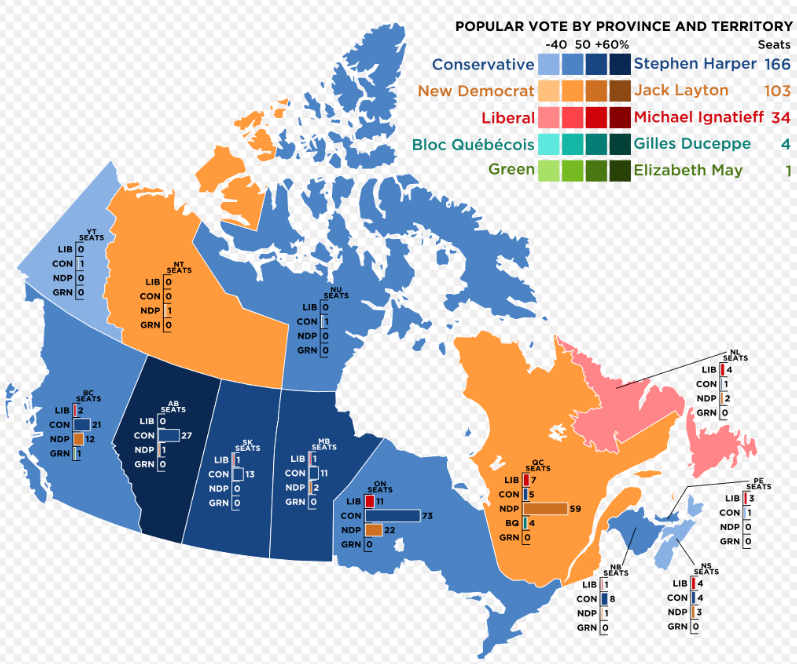

2011 federal results by province

Source: [Wikimedia Commons](https://commons.wikimedia.org/wiki/File:Canada_2011_Federal_Election.svg)

## An attempt at historical borders…

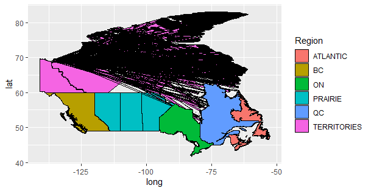

Attempt to remove the NWT – Nunavut border (1949 – 99)

## Shortcomings of Dashboard

- Party strategy will necessarily be different under any form of PR. For instance, the Alba Party only ran list (additional PR MSPs) candidates in the May 2021 Scottish Parliament election.
- Does not consider seats at dissolution / dropping of writ; election broadcast coverage change is reported relative to that instead of the prior election
- Does not take into account redistributions
- May inaccurately account for removals of candidates by the parties after the ballot deadline, e.g. Spadina—Fort York, Toronto in the September 2021 snap Canadian federal election.